# Traffic Sign Recognition Classifier

## Step 0: Load The Data

```python
import pickle       # Load pickled data
import numpy as np  # Load numpy
import tensorflow as tf # Load tensorflow
import pandas as pd
import cv2
from tqdm import tqdm
from sklearn.utils import shuffle
from sklearn import preprocessing
from skimage import color
from PIL import Image
from skimage import exposure
import time
import tensorflow as tf
from tensorflow.contrib.layers import flatten
import matplotlib.pyplot as plt
# Visualizations will be shown in the notebook.
%matplotlib inline
```

```python
# TODO: Fill this in based on where you saved the training and testing data
def load_data(file):
    with open(file, mode='rb') as f:
        data = pickle.load(f)
    return data['features'], data['labels']

X_train, y_train = load_data("train.p")
X_validation, y_validation = load_data("valid.p")
X_test, y_test = load_data("test.p")
label_names = pd.read_csv("signnames.csv",index_col=0, parse_dates=True)
```

## Step 1: Dataset Summary & Exploration

The pickled data is a dictionary with 4 key/value pairs:

- `'features'` is a 4D array containing raw pixel data of the traffic sign images, (num examples, width, height, channels).
- `'labels'` is a 1D array containing the label/class id of the traffic sign. The file `signnames.csv` contains id -> name mappings for each id.
- `'sizes'` is a list containing tuples, (width, height) representing the original width and height the image.
- `'coords'` is a list containing tuples, (x1, y1, x2, y2) representing coordinates of a bounding box around the sign in the image. **THESE COORDINATES ASSUME THE ORIGINAL IMAGE. THE PICKLED DATA CONTAINS RESIZED VERSIONS (32 by 32) OF THESE IMAGES**

Complete the basic data summary below. Use python, numpy and/or pandas methods to calculate the data summary rather than hard coding the results. For example, the [pandas shape method](http://pandas.pydata.org/pandas-docs/stable/generated/pandas.DataFrame.shape.html) might be useful for calculating some of the summary results.

### Basic Summary of the Data Set Using Python, Numpy and/or Pandas

In the pickle files we have

- 34799 training images
- 4410 validation images
- 12630 testing images
- Each Image is of size (32x32x3)
- We have total of 43 classes

```python
### Replace each question mark with the appropriate value.
### Use python, pandas or numpy methods rather than hard coding the results

# TODO: Number of training examples
n_train = y_train.size

# TODO: Number of validation examples
n_validation = y_validation.size

# TODO: Number of testing examples.
n_test = y_test.size

# TODO: What's the shape of an traffic sign image?
image_shape = X_train.shape[1:]

# TODO: How many unique classes/labels there are in the dataset.
n_classes = np.unique(y_train).size

img_size = X_train.shape[1]

print("Number of training examples =", n_train)
print("Number of validation examples =", n_validation)
print("Number of testing examples =", n_test)
print("Image data shape =", image_shape)
print("Number of classes =", n_classes)
```

```
Number of training examples = 34799
Number of validation examples = 4410
Number of testing examples = 12630
Image data shape = (32, 32, 3)
Number of classes = 43
```

## Visualization of the dataset

### The Below Cell Displays the number of classes and sign name for each class in out data

- There are total of 43 classes
- Each class has a unique sign name and unique class id
- In target vector we are referencing the classes by class id and not sign name
- Which means if the target is 0 then the class name is Speed limit (20km/h)

```python
print(label_names)
```

```
                                                  SignName
ClassId
0                                     Speed limit (20km/h)
1                                     Speed limit (30km/h)
2                                     Speed limit (50km/h)
3                                     Speed limit (60km/h)
4                                     Speed limit (70km/h)
5                                     Speed limit (80km/h)
6                              End of speed limit (80km/h)
7                                    Speed limit (100km/h)
8                                    Speed limit (120km/h)
9                                               No passing
10            No passing for vehicles over 3.5 metric tons
11                   Right-of-way at the next intersection
12                                           Priority road
```

[output cut: 30 more lines]

### The below cell displays one training image using matplotlib

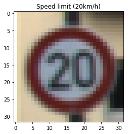

```python
### Data exploration visualization code goes here.
### Feel free to use as many code cells as needed.
unique_labels = np.unique(y_train)
where = np.where(y_train == unique_labels[0])
img = X_train[where[0][0]]
label_name = label_names.ix[0]
plt.title(label_name["SignName"])
plt.imshow(img)
```

### The below cell displays one image from each class. The class label name is the title at the top of image

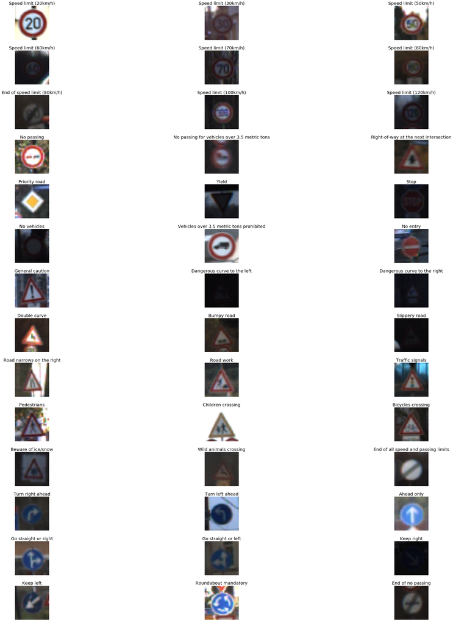

```python
def display_image_per_class(data, target):
    fig1, axes_array =  plt.subplots(14,3, figsize=(40,40))
    fig1.set_size_inches(40, 40)
    i = 0
    for row in range(0, 14):
        for col in range(0, 3):
            where = np.where(target == unique_labels[i])
            image = data[where[0][5]]
            axes_array[row, col].imshow(image)
            axes_array[row, col].axis('off')
            label_name = label_names.ix[i]
            axes_array[row, col].set_title(label_name["SignName"], fontsize=20)
            i += 1
    plt.tight_layout()
    plt.show()

display_image_per_class(X_train, y_train)
```

### Histogram for number of images per class

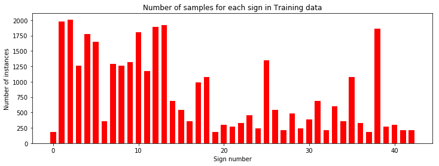

```python
def get_no_of_samples():
    no_of_samples = []
    for i in range(unique_labels.shape[0]):
        where = np.where(y_train == unique_labels[i])
        no_of_samples.append(len(where[0]))
    return no_of_samples

def show_labels_vs_instances_bar():
    samples_per_class = get_no_of_samples()
    N = len(samples_per_class)
    x = range(N)
    width = 1/1.5
    plt.figure(figsize=(12, 4))
    plt.title("Number of samples for each sign in Training data")
    plt.ylabel("Number of instances")
    plt.xlabel("Sign number")
    plt.bar(x, samples_per_class, width, color="red")

show_labels_vs_instances_bar()
```

## Step 2: Design and Test a Model Architecture

### Pre-processing

```python
def eq_Hist(img):
    # =======================
    # Histogram Equalization
    # =======================
    img_copy=img.copy()
    img_copy[:, :, 0] = cv2.equalizeHist(img[:, :, 0])
    img_copy[:, :, 1] = cv2.equalizeHist(img[:, :, 1])
    img_copy[:, :, 2] = cv2.equalizeHist(img[:, :, 2])
    return img_copy
```

```python
def crop(img, mar=0):
    c_x,c_y, sh = int(img.shape[0]/2), int(img.shape[1]/2), int(img_size/2-mar)
    return img[(c_x-sh):(c_x+sh),(c_y-sh):(c_y+sh)]
```

```python
def sharpen_img(img):
    gaussian = cv2.GaussianBlur(img, (5,5), 20.0)
    return cv2.addWeighted(img, 2, gaussian, -1, 0)
```

```python
#Compute linear image transformation ing*s+m
def lin_img(img,s=1.0,m=0.0):
    img2=cv2.multiply(img, np.array([s]))
    return cv2.add(img2, np.array([m]))
```

```python
#Change image contrast; s>1 - increase
def contr_img(img, s=1.0):
    m=127.0*(1.0-s)
    return lin_img(img, s, m)
```

```python
def transform_img(img):
    img2=sharpen_img(img)
    img2=crop(img2,3)
    img2=contr_img(img2, 1.5)
    return eq_Hist(img2)
```

```python
### Preprocess the data here. It is required to normalize the data. Other preprocessing steps could include
### converting to grayscale, etc.
### Feel free to use as many code cells as needed.
def preprocess(data):
    scaled_data = [] # np.zeros((data.shape[0], data.shape[1], data.shape[2]))

    for i in range(0, data.shape[0]):
        img = transform_img(data[i])
        img = img/255.0
        scaled_data.append(img)
    return np.array(scaled_data)

X_train = preprocess(X_train)
X_validation = preprocess(X_validation)
X_test  = preprocess(X_test)

print("Single training image shape =", X_train[0].shape)
```

```
Single training image shape = (26, 26, 3)
```

### Pre-processing techniques used

**The below cell displays the images after pre-processing which will give a better idea of the results of my pipeline and you can compare these pre-processed images with the raw images displayed above**

### Images after preprocessing

- The below cell displays the image after pre-processing pipeline is applied
- And now each image is of 26x26x3 dimension

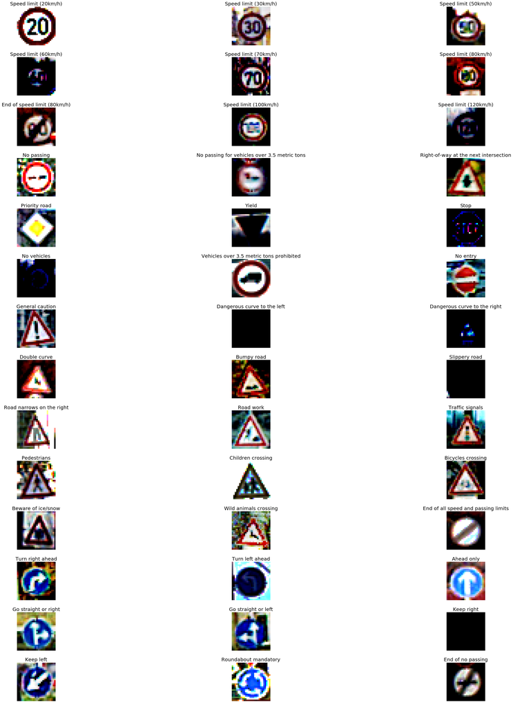

```python
display_image_per_class(X_train, y_train)
```

### Data Augmentation

- After doing data visualisation on our raw data I was sure that data sugmentation is necessary for our model to perform better
- The data provided for training is not enough
- many classes of our training data as described in the **Data Visualization** has less number for training data.
- It is possible that there is a chance of bias training as many classes has lot's of training data while many classes have less training data
- Because of less data for few classes the model will give prediction of the data for the class it has seen the most
- This is what I thought of and decided that there has to be data augmentation needed

```python
import keras
from keras.preprocessing.image import ImageDataGenerator

datagen = keras.preprocessing.image.ImageDataGenerator(
    rotation_range=8,
    width_shift_range=0.1,
    height_shift_range=0.1,
    shear_range=0.1,
    zoom_range=0.1,
    fill_mode='nearest',
    horizontal_flip=False,
    vertical_flip=False
)
```

### Below cell does the data augmentation to our training data

- The data is created by rotating the images in the train data, shifting the images in x direction and y direction
- Used Keras for creating the images

```python
total_image_per_class = 5000
X_train_augmented = np.empty((0,26,26,3))
y_train_augmented = np.empty(0,dtype='uint8')

for i in tqdm(range(n_classes)):
    index = [y_train==i]
    images_for_i_class = X_train[y_train==i]
    y_i_class = y_train[y_train==i]

    X_train_augmented_i = np.copy(images_for_i_class)
    y_train_augmented_i = np.copy(y_i_class)

    for X,y in datagen.flow(images_for_i_class, y_i_class, batch_size=len(y_i_class), seed=9345+i*37):
        X_train_augmented_i = np.append(X_train_augmented_i, X, axis=0)
        y_train_augmented_i = np.append(y_train_augmented_i, y, axis=0)

        if len(X_train_augmented_i) >= total_image_per_class:
            break

    X_train_augmented = np.append(X_train_augmented, X_train_augmented_i[:5000], axis=0)
    y_train_augmented = np.append(y_train_augmented, y_train_augmented_i[:5000], axis=0)

print("Augmented data shape =", X_train_augmented.shape)
print("Training data shape", X_train.shape)
X_train = np.concatenate((X_train, X_train_augmented))
y_train = np.concatenate((y_train, y_train_augmented))
X_train = X_train.astype('float64')
print("Training data shape after adding the augmented data", X_train.shape)

X_train, y_train = shuffle(X_train, y_train)
```

```
Augmented data shape = (215000, 26, 26, 3)
Training data shape (34799, 26, 26, 3)
Training data shape after adding the augmented data (249799, 26, 26, 3)
```

### The below cell displays the Augmented images by Keras

- You can see one example of each class

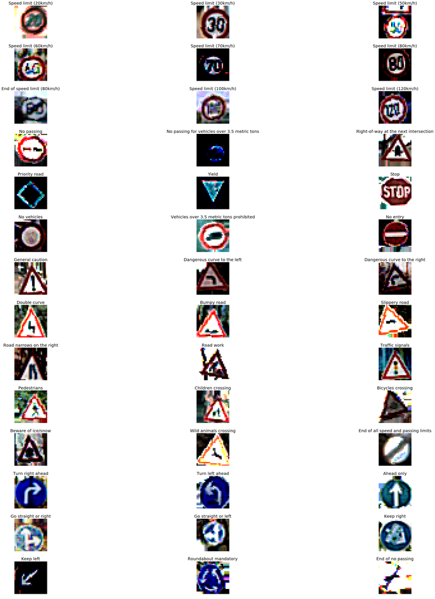

```python
X_train_augmented, y_train_augmented = shuffle(X_train_augmented, y_train_augmented)
display_image_per_class(X_train_augmented, y_train_augmented)
```

```python
### Replace each question mark with the appropriate value.
### Use python, pandas or numpy methods rather than hard coding the results

# TODO: Number of training examples
n_train = y_train.size

# TODO: Number of validation examples
n_validation = y_validation.size

# TODO: Number of testing examples.
n_test = y_test.size

# TODO: What's the shape of an traffic sign image?
image_shape = X_train.shape[1:]

# TODO: How many unique classes/labels there are in the dataset.
n_classes = np.unique(y_train).size

print("Number of training examples =", n_train)
print("Number of testing examples =", n_test)
print("Image data shape =", image_shape)
print("Number of classes =", n_classes)
print("max value of first data =", np.amax(X_train))
```

```
Number of training examples = 249799
Number of testing examples = 12630
Image data shape = (26, 26, 3)
Number of classes = 43
max value of first data = 1.0
```

### Data Visualization after Data Augmentation

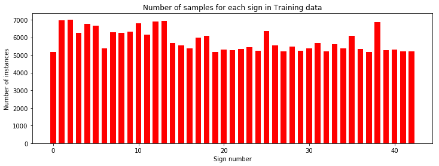

```python
show_labels_vs_instances_bar()
```

## Setup TensorFlow

The `EPOCH` and `BATCH_SIZE` values affect the training speed and model accuracy.

You do not need to modify this section.

```python
EPOCHS = 10
BATCH_SIZE = 128
```

### Model used and it's characteristics

- My model is based on Google's famous inception architecture
- I think There are many better models for classifying images than Lenet
- Google's inception module is a better architecture than Lenet so I have decided to use it
- The model takes image of dimension 26x26x3
- The Model has follwing description:

| Layer | Description |
| --- | --- |
| Input | 26x26x3 image |
| Convolution 1x1 | 1x1 stride, SAME padding, outputs 26x26x3 |
| RELU |  |
| Convolution 5x5 | 1x1 stride, SAME padding, outputs 26x26x64 |
| RELU |  |
| Inception-1 | outputs 26x26x256 |
| Max pooling 2x2 | 2x2 stride, outputs 13x13x256 |
| Inception-2 | outputs 13x13x512 |
| Max pooling 3x3 | 2x2 stride, outputs 6x6x512 |
| Convolution | outputs 6x6x256 |
| Fully connected | input 9216, output 512 |
| RELU |  |
| Dropout | 75% keep |
| Fully connected | input 512, output 43 |

- To know more about Google's Inception architecture please refer the paper [GoogleNet](https://www.cs.unc.edu/~wliu/papers/GoogLeNet.pdf).

### Model Architecture

```python
### Define your architecture here.
### Feel free to use as many code cells as needed.

# Hyperparameters
mu = 0.0
sigma = 0.1
dropout = 0.75 #dropout rate

#number of outputs on the first and the second inception modules
d_1 = 64
d_2 = 128
d_1x1 = 32
```

```python
def maxpool_layer(x, filter_w):
    return tf.nn.max_pool(x,ksize=[1,filter_w,filter_w,1], strides=[1,1,1,1],padding='SAME')

def maxpool_stride_layer(x, filter_w, s):
    return tf.nn.max_pool(x,ksize=[1,filter_w,filter_w,1], strides=[1,s,s,1],padding='VALID')

def conv_layer(x, filter_w, in_d, out_d, is_relu):
    conv_W = tf.Variable(tf.truncated_normal(shape=(filter_w, filter_w, in_d, out_d), mean = mu, stddev = sigma))
    conv_b = tf.Variable(tf.zeros(out_d))
    conv_res   = tf.nn.conv2d(x, conv_W, strides=[1, 1, 1, 1], padding='SAME') + conv_b
    if is_relu:
        return tf.nn.relu(conv_res)
    else:
        return conv_res
```

```python
def apply_inception(x, in_d, out_d):
    conv1x1 = conv_layer(x, 1, in_d, out_d, True)
    conv2 = conv_layer(x, 1, in_d, d_1x1, True)
    conv3 = conv_layer(x, 1, in_d, d_1x1, True)
    maxpool = maxpool_layer(x, 3)
    conv_maxpool = conv_layer(maxpool, 1, in_d, out_d, False)
    conv3x3 = conv_layer(conv2, 3, d_1x1, int(out_d/2), False)
    conv3x3 = conv_layer(conv3x3, 1, int(out_d/2), out_d, False)
    conv5x5 = conv_layer(conv3, 5, d_1x1, int(out_d/2), False)
    conv5x5 = conv_layer(conv5x5, 1, int(out_d/2), out_d, False)
    return tf.nn.relu(tf.concat(3, [conv1x1, conv3x3, conv5x5, conv_maxpool]))
```

```python
def Model(x, out=43):
    conv1 = conv_layer(x, 1, 3, 3, True)             # Output is 26x26x3
    conv2 = conv_layer(conv1, 5, 3, 64, True)        # Output is 26x26x64
    incept1 = apply_inception(conv2, 64, d_1)        # Output is 26x26x256
    maxpool1 = maxpool_stride_layer(incept1, 2, 2)   # Output is 13x13x256
    incept2 = apply_inception(maxpool1, d_1*4, d_2)  # Output is 13x13x512
    maxpool2 = maxpool_stride_layer(incept2, 3, 2)   # Output is 6x6x512
    conv3 = conv_layer(maxpool2, 1, 512, 256, False) # Output is 6x6x256


    fc0 = flatten(conv3)
    fc0_W = tf.Variable(tf.truncated_normal(shape=(9216, 512), mean = mu, stddev = sigma))
    fc0_b = tf.Variable(tf.zeros(512))

    fc1 = tf.matmul(fc0, fc0_W) + fc0_b
    fc1 = tf.nn.relu(fc1)
    fc1 = tf.nn.dropout(fc1, dropout)

    fc2_W  = tf.Variable(tf.truncated_normal(shape=(512, out), mean = mu, stddev = sigma))
    fc2_b  = tf.Variable(tf.zeros(out))
    logits = tf.matmul(fc1, fc2_W) + fc2_b
    return logits
```

### Train, Validate and Test the Model

A validation set can be used to assess how well the model is performing. A low accuracy on the training and validation sets imply underfitting. A high accuracy on the training set but low accuracy on the validation set implies overfitting.

## Features and Labels

Train LeNet to classify [German Traffic Sign Dataset](http://benchmark.ini.rub.de/?section=gtsrb&subsection=dataset) data.

`x` is a placeholder for a batch of input images. `y` is a placeholder for a batch of output labels.

You do not need to modify this section.

```python
### Train your model here.
### Calculate and report the accuracy on the training and validation set.
### Once a final model architecture is selected,
### the accuracy on the test set should be calculated and reported as well.
### Feel free to use as many code cells as needed.
x = tf.placeholder(tf.float32, (None, 26, 26, 3))
y = tf.placeholder(tf.int32, (None))
one_hot_y = tf.one_hot(y, 43)
```

## Training Pipeline

Create a training pipeline that uses the model to classify German Traffic Sign Dataset data.

You do not need to modify this section.

### Model training description

- I have trained the model for 10 epochs
- I tried training for 30 epochs but it seems the method I have used for pre-processing and models used there is not much changes in the validation accuracy for the model
- I have used bacth size of 128. I have choosen this because tensorflow gives optimized results when batch size is a power of 2
- learning rate used is 0.001. I think this is ideal leanring rate to start with or may be 0.01
- Used AdamOptimizer to optimize out cost function.
- AdamOptimizer is better than other optimizers. It helps in adaptive leanring and is useful for large data with model having lot's of hyperparmaters and anyways it was default optimizer when i tried Lenet on The traffic sign

```python
alpha = 0.001

logits = Model(x)
cross_entropy = tf.nn.softmax_cross_entropy_with_logits(logits = logits, labels = one_hot_y)
loss_operation = tf.reduce_mean(cross_entropy)
optimizer = tf.train.AdamOptimizer(learning_rate = alpha)
training_operation = optimizer.minimize(loss_operation)
```

## Model Evaluation

Evaluate how well the loss and accuracy of the model for a given dataset.

You do not need to modify this section.

```python
correct_prediction = tf.equal(tf.argmax(logits, 1), tf.argmax(one_hot_y, 1))
accuracy_operation = tf.reduce_mean(tf.cast(correct_prediction, tf.float32))
saver = tf.train.Saver()

def evaluate(X_data, y_data):
    num_examples = len(X_data)
    total_accuracy = 0
    sess = tf.get_default_session()
    for offset in range(0, num_examples, BATCH_SIZE):
        batch_x, batch_y = X_data[offset:offset+BATCH_SIZE], y_data[offset:offset+BATCH_SIZE]
        accuracy = sess.run(accuracy_operation, feed_dict={x: batch_x, y: batch_y})
        total_accuracy += (accuracy * len(batch_x))
    return total_accuracy / num_examples
```

## Train the Model

Run the training data through the training pipeline to train the model.

Before each epoch, shuffle the training set.

After each epoch, measure the loss and accuracy of the validation set.

Save the model after training.

You do not need to modify this section.

```python
with tf.Session() as sess:
    sess.run(tf.global_variables_initializer())
    num_examples = len(X_train)

    print("Training...")
    print()
    for i in range(EPOCHS):
        X_train, y_train = shuffle(X_train, y_train)
        for offset in tqdm(range(0, num_examples, BATCH_SIZE)):
            end = offset + BATCH_SIZE
            batch_x, batch_y = X_train[offset:end], y_train[offset:end]
            sess.run(training_operation, feed_dict={x: batch_x, y: batch_y})

        validation_accuracy = evaluate(X_validation, y_validation)
        print("EPOCH {} ...".format(i+1))
        print("Validation Accuracy = {:.3f}".format(validation_accuracy))
        print()

    saver.save(sess, './my_model')
    print("Model saved")
```

```
Training...
```

```
EPOCH 1 ...
Validation Accuracy = 0.939
```

```
EPOCH 2 ...
Validation Accuracy = 0.938
```

```
EPOCH 3 ...
Validation Accuracy = 0.936
```

```
EPOCH 4 ...
Validation Accuracy = 0.933
```

```
EPOCH 5 ...
Validation Accuracy = 0.938
```

```
EPOCH 6 ...
Validation Accuracy = 0.945
```

```
EPOCH 7 ...
Validation Accuracy = 0.934
```

```
EPOCH 8 ...
Validation Accuracy = 0.943
```

```
EPOCH 9 ...
Validation Accuracy = 0.917
```

```
EPOCH 10 ...
Validation Accuracy = 0.937

Model saved
```

## Evaluate the Model

Once you are completely satisfied with your model, evaluate the performance of the model on the test set.

Be sure to only do this once!

If you were to measure the performance of your trained model on the test set, then improve your model, and then measure the performance of your model on the test set again, that would invalidate your test results. You wouldn't get a true measure of how well your model would perform against real data.

You do not need to modify this section.

```python
# Run testing
with tf.Session() as sess:
    saver.restore(sess, './my_model')
    test_accuracy = evaluate(X_test, y_test)
    print("Test Accuracy = {:.3f}".format(test_accuracy))
```

```
Test Accuracy = 0.935
```

## Step 3: Test a Model on New Images

To give yourself more insight into how your model is working, download at least five pictures of German traffic signs from the web and use your model to predict the traffic sign type.

You may find `signnames.csv` useful as it contains mappings from the class id (integer) to the actual sign name.

### Load and Output the Images

- For custom test images it is necessay to apply the same pre-processing pipeline
- So the below cell simply reads the custom test images from a folder and applies pre-processing pipeline discussed earlier
- After applying the the pre-processing in all the images it is stored as a numpy array

```python
### Load the images and plot them here.
### Feel free to use as many code cells as needed.
import glob

def load_data(file):
    data = []
    target = []
    for filename in glob.glob(file + '/*.jpg'):
        x, y = filename.split("/")
        img = cv2.imread(filename)
        img = transform_img(img)
        img = img/255.0
        data.append(img)
        target.append(int(y[0: 2]))
    return np.array(data), np.array(target)

X_custom_test, y_custom_test = load_data("custom_data")

print("Shape of custom test data =", X_custom_test.shape)
print("Number of custom test data =", y_custom_test.shape[0])
```

```
Shape of custom test data = (8, 26, 26, 3)
Number of custom test data = 8
```

### Custom Test Data

- The below cell shows all the custom test images with their actual ground truth as it's title

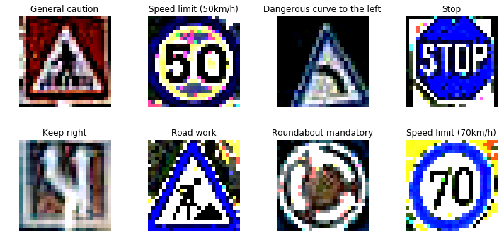

```python
def display_custom_test_images(data, target):
    fig1, axes_array =  plt.subplots(2, 4, figsize=(12,24))
    fig1.set_size_inches(10, 5)
    i = 0
    for row in range(0, 2):
        for col in range(0, 4):
            axes_array[row, col].imshow(X_custom_test[i])
            axes_array[row, col].axis('off')
            label_name = label_names.ix[target[i]]
            axes_array[row, col].set_title(label_name["SignName"])
            i += 1
    plt.tight_layout()
    plt.show()

display_custom_test_images(X_custom_test, y_custom_test)
```

### Predict the Sign Type for Each Image

- The below cell will display the model prediction for each custom test image
- The models prediction are shown as title which is at the top of each custom test image

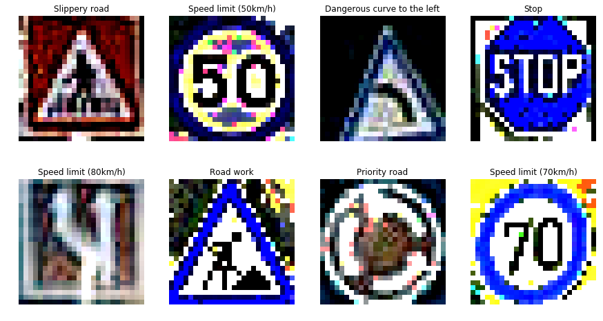

```python
### Run the predictions here and use the model to output the prediction for each image.
### Make sure to pre-process the images with the same pre-processing pipeline used earlier.
### Feel free to use as many code cells as needed.
def prediction_net(X_data, sess):
    pred_sign = sess.run(tf.argmax(logits, 1), feed_dict={x: X_data})
    return pred_sign

with tf.Session() as sess:
    saver.restore(sess, './my_model')
    signs_classes = prediction_net(X_custom_test, sess)


plt.figure(figsize=(15, 8))
for i in range(8):
    plt.subplot(2, 4, i+1)
    plt.imshow(X_custom_test[i])
    plt.title(label_names.ix[signs_classes[i]]["SignName"])
    plt.axis('off')
plt.show()
```

The above prediction summary is as follows :

[output not shown]

### Analyze Performance

```python
### Calculate the accuracy for these 5 new images.
### For example, if the model predicted 1 out of 5 signs correctly, it's 20% accurate on these new images.
with tf.Session() as sess:
    saver.restore(sess, './my_model')
    test_accuracy = evaluate(X_custom_test, y_custom_test)
    print("Test Accuracy = {:.3f}".format(test_accuracy))
```

```
Test Accuracy = 0.750
```

### Output Top 5 Softmax Probabilities For Each Image Found on the Web

For each of the new images, print out the model's softmax probabilities to show the **certainty** of the model's predictions (limit the output to the top 5 probabilities for each image). [`tf.nn.top_k`](https://www.tensorflow.org/versions/r0.12/api_docs/python/nn.html#top_k) could prove helpful here.

The example below demonstrates how tf.nn.top_k can be used to find the top k predictions for each image.

`tf.nn.top_k` will return the values and indices (class ids) of the top k predictions. So if k=3, for each sign, it'll return the 3 largest probabilities (out of a possible 43) and the correspoding class ids.

Take this numpy array as an example. The values in the array represent predictions. The array contains softmax probabilities for five candidate images with six possible classes. `tf.nn.top_k` is used to choose the three classes with the highest probability:

```
# (5, 6) array
a = np.array([[ 0.24879643,  0.07032244,  0.12641572,  0.34763842,  0.07893497,
         0.12789202],
       [ 0.28086119,  0.27569815,  0.08594638,  0.0178669 ,  0.18063401,
         0.15899337],
       [ 0.26076848,  0.23664738,  0.08020603,  0.07001922,  0.1134371 ,
         0.23892179],
       [ 0.11943333,  0.29198961,  0.02605103,  0.26234032,  0.1351348 ,
         0.16505091],
       [ 0.09561176,  0.34396535,  0.0643941 ,  0.16240774,  0.24206137,
         0.09155967]])
```

Running it through `sess.run(tf.nn.top_k(tf.constant(a), k=3))` produces:

```
TopKV2(values=array([[ 0.34763842,  0.24879643,  0.12789202],
       [ 0.28086119,  0.27569815,  0.18063401],
       [ 0.26076848,  0.23892179,  0.23664738],
       [ 0.29198961,  0.26234032,  0.16505091],
       [ 0.34396535,  0.24206137,  0.16240774]]), indices=array([[3, 0, 5],
       [0, 1, 4],
       [0, 5, 1],
       [1, 3, 5],
       [1, 4, 3]], dtype=int32))
```

Looking just at the first row we get `[ 0.34763842, 0.24879643, 0.12789202]`, you can confirm these are the 3 largest probabilities in `a`. You'll also notice `[3, 0, 5]` are the corresponding indices.

```python
### Print out the top five softmax probabilities for the predictions on the German traffic sign images found on the web.
### Feel free to use as many code cells as needed.
def get_top_5(X_data, sess):
    probabilities = sess.run(tf.nn.softmax(logits), feed_dict={x: X_data})
    top_5_values = tf.nn.top_k(probabilities, k=5)
    return sess.run(top_5_values)


with tf.Session() as sess:
    saver.restore(sess, './my_model')
    top_5_signs = get_top_5(X_custom_test, sess)
    print(top_5_signs)
```

```
TopKV2(values=array([[  8.91978085e-01,   8.89552310e-02,   1.65576041e-02,
          2.50495272e-03,   3.68445308e-06],
       [  9.99999881e-01,   6.58213395e-08,   2.73503620e-09,
          2.72660285e-13,   1.11826094e-14],
       [  1.00000000e+00,   1.07187777e-23,   5.38977074e-35,
          4.83080653e-35,   1.01202057e-35],
       [  1.00000000e+00,   2.59813068e-22,   7.54864513e-26,
          1.85501484e-31,   1.59642877e-31],
       [  7.01461554e-01,   1.69148162e-01,   5.32663092e-02,
          5.10480180e-02,   1.06339166e-02],
       [  1.00000000e+00,   9.23947442e-13,   7.14158148e-16,
          1.85091739e-21,   5.13414382e-24],
       [  5.29770315e-01,   2.95625865e-01,   5.66688962e-02,
          4.64931242e-02,   2.65703872e-02],
       [  9.99999762e-01,   2.89460615e-07,   2.40763334e-12,
          1.87910169e-12,   1.99183294e-13]], dtype=float32), indices=array([[29, 30, 23, 22, 28],
       [ 2,  1, 38, 40, 10],
       [19, 23, 38, 11, 24],
       [14, 34, 38, 33,  5],
       [20, 21, 29, 24, 30],
       [25, 30, 23, 22, 29],
       [12, 40, 16,  5,  7],
       [ 4,  1,  2,  0, 18]], dtype=int32))
```

```python
for i in range(len(top_5_signs[0])):
    print("For image", i, "\n \t top 5 values are :\n \t", top_5_signs[0][i], "\n \t and index values are \n \t", top_5_signs[1][i])
```

```
For image 0
 	 top 5 values are :
 	 [  8.91978085e-01   8.89552310e-02   1.65576041e-02   2.50495272e-03
   3.68445308e-06]
 	 and index values are
 	 [29 30 23 22 28]
For image 1
 	 top 5 values are :
 	 [  9.99999881e-01   6.58213395e-08   2.73503620e-09   2.72660285e-13
   1.11826094e-14]
 	 and index values are
 	 [ 2  1 38 40 10]
For image 2
 	 top 5 values are :
 	 [  1.00000000e+00   1.07187777e-23   5.38977074e-35   4.83080653e-35
   1.01202057e-35]
 	 and index values are
 	 [19 23 38 11 24]
For image 3
 	 top 5 values are :
 	 [  1.00000000e+00   2.59813068e-22   7.54864513e-26   1.85501484e-31
   1.59642877e-31]
 	 and index values are
 	 [14 34 38 33  5]
For image 4
 	 top 5 values are :
 	 [ 0.70146155  0.16914816  0.05326631  0.05104802  0.01063392]
 	 and index values are
 	 [20 21 29 24 30]
For image 5
 	 top 5 values are :
 	 [  1.00000000e+00   9.23947442e-13   7.14158148e-16   1.85091739e-21
   5.13414382e-24]
 	 and index values are
 	 [25 30 23 22 29]
For image 6
 	 top 5 values are :
 	 [ 0.52977031  0.29562587  0.0566689   0.04649312  0.02657039]
 	 and index values are
 	 [12 40 16  5  7]
For image 7
 	 top 5 values are :
 	 [  9.99999762e-01   2.89460615e-07   2.40763334e-12   1.87910169e-12
   1.99183294e-13]
 	 and index values are
 	 [ 4  1  2  0 18]
```

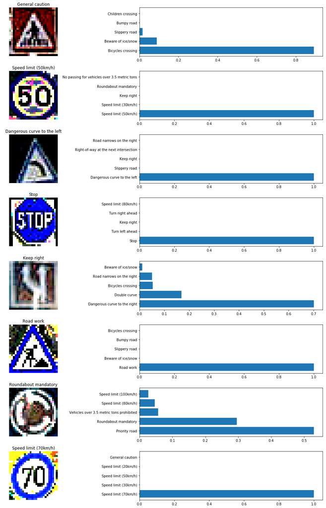

```python
plt.figure(figsize=(16, 21))
for i in range(8):
    plt.subplot(8, 2, 2*i+1)
    plt.imshow(X_custom_test[i])
    label_name = label_names.ix[y_custom_test[i]]
    plt.title(label_name["SignName"])
    plt.axis('off')
    plt.subplot(8, 2, 2*i+2)
    plt.barh(np.arange(1, 6, 1), top_5_signs.values[i, :])
    labs=[label_names.ix[j]["SignName"] for j in top_5_signs.indices[i]]
    plt.yticks(np.arange(1, 6, 1), labs)
    plt.tight_layout()
plt.tight_layout()
plt.show()
```

### Project Writeup

Once you have completed the code implementation, document your results in a project writeup using this [template](https://github.com/udacity/CarND-Traffic-Sign-Classifier-Project/blob/master/writeup_template.md) as a guide. The writeup can be in a markdown or pdf file.

## Step 4 (Optional): Visualize the Neural Network's State with Test Images

This Section is not required to complete but acts as an additional excersise for understaning the output of a neural network's weights. While neural networks can be a great learning device they are often referred to as a black box. We can understand what the weights of a neural network look like better by plotting their feature maps. After successfully training your neural network you can see what it's feature maps look like by plotting the output of the network's weight layers in response to a test stimuli image. From these plotted feature maps, it's possible to see what characteristics of an image the network finds interesting. For a sign, maybe the inner network feature maps react with high activation to the sign's boundary outline or to the contrast in the sign's painted symbol.

Provided for you below is the function code that allows you to get the visualization output of any tensorflow weight layer you want. The inputs to the function should be a stimuli image, one used during training or a new one you provided, and then the tensorflow variable name that represents the layer's state during the training process, for instance if you wanted to see what the LeNet lab's feature maps looked like for it's second convolutional layer you could enter conv2 as the tf_activation variable.

For an example of what feature map outputs look like, check out NVIDIA's results in their paper [End-to-End Deep Learning for Self-Driving Cars](https://devblogs.nvidia.com/parallelforall/deep-learning-self-driving-cars/) in the section Visualization of internal CNN State. NVIDIA was able to show that their network's inner weights had high activations to road boundary lines by comparing feature maps from an image with a clear path to one without. Try experimenting with a similar test to show that your trained network's weights are looking for interesting features, whether it's looking at differences in feature maps from images with or without a sign, or even what feature maps look like in a trained network vs a completely untrained one on the same sign image.

[figure not shown]

Your output should look something like this (above)

```python
### Visualize your network's feature maps here.
### Feel free to use as many code cells as needed.

# image_input: the test image being fed into the network to produce the feature maps
# tf_activation: should be a tf variable name used during your training procedure that represents the calculated state of a specific weight layer
# activation_min/max: can be used to view the activation contrast in more detail, by default matplot sets min and max to the actual min and max values of the output
# plt_num: used to plot out multiple different weight feature map sets on the same block, just extend the plt number for each new feature map entry

def outputFeatureMap(image_input, tf_activation, activation_min=-1, activation_max=-1 ,plt_num=1):
    # Here make sure to preprocess your image_input in a way your network expects
    # with size, normalization, ect if needed
    # image_input =
    # Note: x should be the same name as your network's tensorflow data placeholder variable
    # If you get an error tf_activation is not defined it may be having trouble accessing the variable from inside a function
    activation = tf_activation.eval(session=sess,feed_dict={x : image_input})
    featuremaps = activation.shape[3]
    plt.figure(plt_num, figsize=(15,15))
    for featuremap in range(featuremaps):
        plt.subplot(6,8, featuremap+1) # sets the number of feature maps to show on each row and column
        plt.title('FeatureMap ' + str(featuremap)) # displays the feature map number
        if activation_min != -1 & activation_max != -1:
            plt.imshow(activation[0,:,:, featuremap], interpolation="nearest", vmin =activation_min, vmax=activation_max, cmap="gray")
        elif activation_max != -1:
            plt.imshow(activation[0,:,:, featuremap], interpolation="nearest", vmax=activation_max, cmap="gray")
        elif activation_min !=-1:
            plt.imshow(activation[0,:,:, featuremap], interpolation="nearest", vmin=activation_min, cmap="gray")
        else:
            plt.imshow(activation[0,:,:, featuremap], interpolation="nearest", cmap="gray")
```